# BIAS - tendência

Para que a perceptron "saia do ponto (0,0)", é adicionado um outro fator ao resultado.

Então basta fazer $[\sum_{i = 0}^{n} (W_i*X_i)] + b$ onde $n$ é o número de dados de entrada, $W$ são os pesos e $X$ são as entradas e $b$ é o bias, ou tendência.

$b$ é um numero arbitrario != 0.

Desta forma, o processo fica:

$$ x = [\sum_{i = 0}^{n} (W_i*X_i)] + b $$$$ \sigma(x) = \frac{1}{1 + e^{-x}} $$

#### Imports

```python
import numpy as np
import matplotlib.pyplot as plt
import random
import math
```

#### Código

```python
def sigmoid(x):
    return 1 / (1 + math.exp(-x))
```

```python
# Entrada
points = [[1,0]]
```

```python
# Criando os pesos da perceptron
W = []
N_entrada = 3

for i in range(N_entrada):
    W.append(random.random()*2 -1)
```

```python
W
```

```
[0.8585985776950877, -0.02166610886010023, -0.48227027518644583]
```

```python
def predict(X):
    return sigmoid(sum([w*x for w,x in zip(W, X)]))
```

Adicionar um bias, equivale adicionar um terceiro parâmetro para o dado de entrada, sendo que este sempre será 1, desta forma o Bias será o peso associado ao dado de entrada.

```python
for X in points:
    p = predict([X[0], X[1], 1])
    print(p)
```

```
0.5929872298031833
```

## Visualizando...

Cria-se uma imagem de tamanho arbitrário.

```python
img = np.ones((300, 400))
```

Define-se o tamanho das entradas x e y, sendo que a largura da imagem será o máximo a ser exibido na direção x enquanto que a altura será na direção y.

Então manda-se predizer, com os valores baseados em x e y, sendo que serão convertidos para valores do problema, pintando cada pixel da imagem na posição x e y calculada.

```python
# grab the image dimensions
w = img.shape[0]
h = img.shape[1]

# loop over the image, pixel by pixel
for x in range(0, w):
    for y in range(0, h):
        # threshold the pixel
        img[x][y] = predict([x/w, y/h, 1])
```

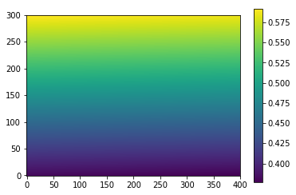

```python
plt.imshow(img, origin='lower')
plt.colorbar()
plt.show()
```

```python
# grab the image dimensions
w = img.shape[0]
h = img.shape[1]

# loop over the image, pixel by pixel
for x in range(0, w):
    for y in range(0, h):
        # threshold the pixel
        if (predict([x/w, y/h, 1]) > 0.5):
            img[x][y] = 1
        else:
            img[x][y] = 0
```

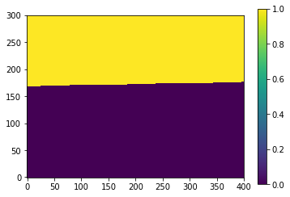

```python
plt.imshow(img, origin='lower')
plt.colorbar()
plt.show()
```